# Relatório do Cadastro Geral de Empregados e Desempregados (CAGED)

Diretoria de Monitoramento e Articulação de Oportunidades de Trabalho - DMAOT/SUBTE

05 março, 2021

**Resumo dos Resultados**

- Brasil
  - Em janeiro de 2021 houve geração líquida de quase 78 mil postos de trabalho no país.
  - Em números absolutos, as Unidades Federativas com maior saldo foram São Paulo (20.278), Rio Grande do Sul (17.769) e Santa Catarina (17.348). Enquanto os saldos mais baixos foram registrados em: Rio de Janeiro (-9.830), Pernambuco (-4.837) e Pará (-4.081).
- Minas Gerais
  - Em Minas Gerais, também em janeiro de 2021, houve geração líquida de mais de 8.3 mil empregos formais.
  - Dos cinco setores de atividade econômica, Indústria, Construção, Serviços e Agropecuária apresentaram saldo de empregos positivo no mês.

# Conheça o CAGED

O Cadastro Geral de Empregados e Desempregados (CAGED) é um registro administrativo que contabiliza, mensalmente, a movimentação de trabalhadores no mercado de trabalho formal, ou seja, o número de admissões e desligamentos de empregados sob o regime da Consolidação das Leis do Trabalho – CLT.

As estatísticas provenientes do CAGED compõem uma das principais fontes informacionais para a elaboração de estudos, pesquisas, projetos e programas ligados ao mercado de trabalho, subsidiando a tomada de decisões para ações governamentais.

# Metodologia

As análises que se seguem foram realizadas a partir dos microdados do [Caged](http://pdet.mte.gov.br/o-que-e-caged) (2019) e [Novo Caged](http://pdet.mte.gov.br/o-que-e-novo-caged) (2020 e 2021) disponibilizados pela Secretaria Especial de Previdência e Trabalho (SEPRT/ME) do Ministério da Economia. Os números apresentados referem-se apenas às declarações enviadas dentro do prazo, para fins de melhor comparabilidade dos dados de janeiro de 2021. Desta forma os resultados apresentados estão sujeitos a alterações nos próximos meses, devido ao processo de incorporação de declarações represadas nas bases dadados.

Cabe salientar que, o quadro pandêmico, assim como a mudança do sistema CAGED para o E-social, causaram distorções nos dados do CAGED ao longo de 2020, sendo necessária bastante cautela na interpretação das análises comparativas entre 2021 e 2020.

# Resultado Nacional

No país, em janeiro de 2021, houve criação líquida de 77.822 postos de empregos formais, resultado de 1.284.498 contratações e 1.206.676 desligamentos. Na comparação com janeiro de 2020 foram 11.000 postos de trabalho gerados a mais.

Já no comparativo com o mesmo mês de 2019, o resultado do saldo foi positivo, com a geração líquida de 43.509 postos de trabalho a mais. O número de admissões diminuiu 3.1% e o total de demissões apresentou recuo de 6.5%.

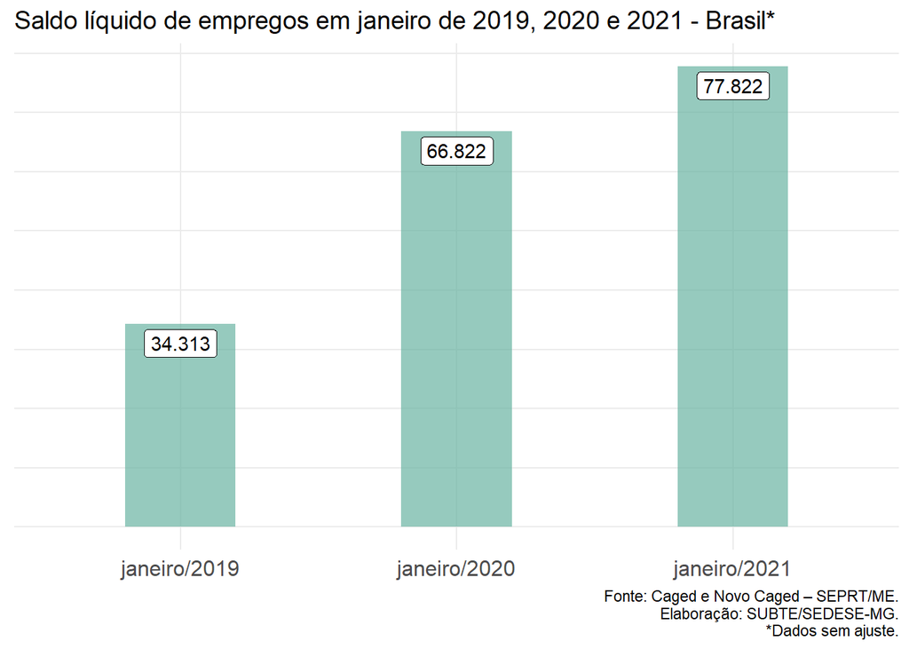

### **Resultado Nacional por Região**

A região Sul foi a que registrou o maior saldo positivo (46.754), seguida pela região Sudeste (21.924) e Centro-Oeste (20.421). Na região Norte foram fechadas -5.242 vagas e, na Nordeste, -6.035 postos de trabalho foram fechados.

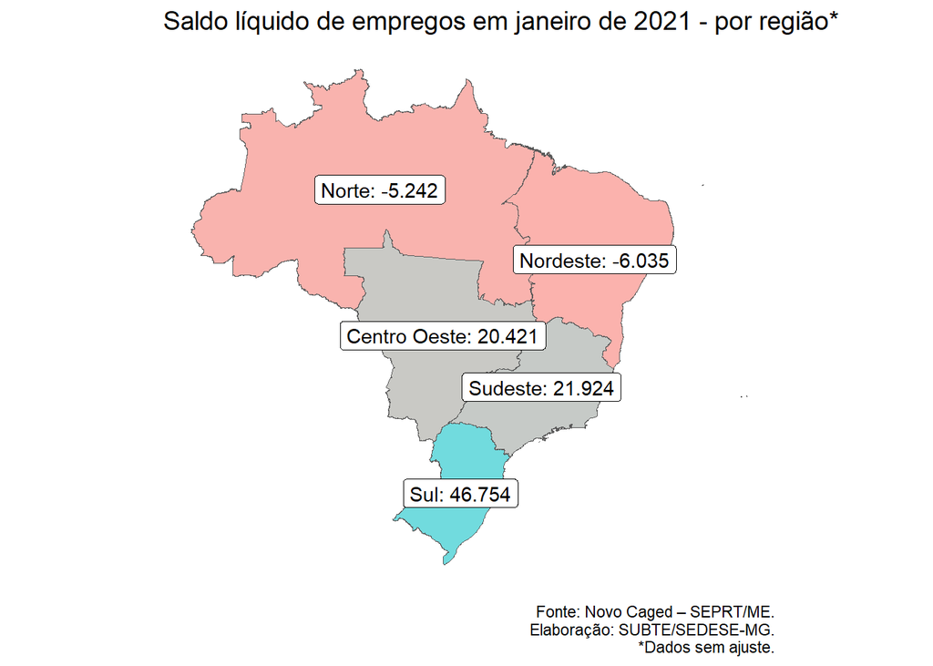

### **Resultado Nacional por Unidade Federativa**

Entre os estados, São Paulo, com 20.278 novas vagas, Rio Grande do Sul, com 17.769, e Santa Catarina, com 17.348, tiveram os maiores saldo no país. Os menores saldos foram os de Rio de Janeiro, com -9.830 vagas, Pernambuco, com -4.837, e Pará com -4.081 vagas.

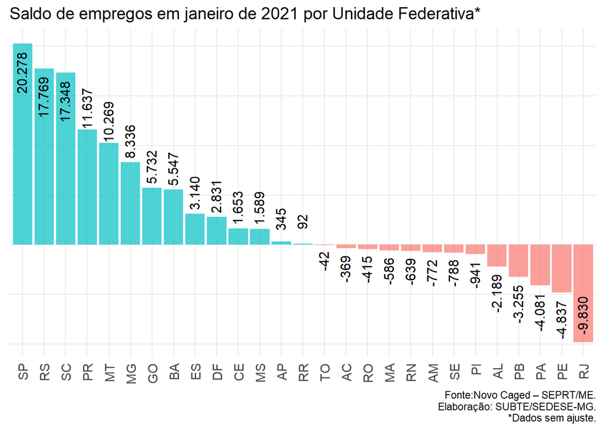

# Resultado Estadual

Apesar da pandemia do coronavírus, Minas Gerais criou 8.336 empregos com carteira assinada em janeiro, resultado de 139.731 contratações menos 131.395 desligamentos.

O desempenho deixou o Estado em 6º lugar no ranking nacional. Na região Sudeste, Minas Gerais ficou em 2º lugar.

No comparativo com janeiro de 2020, as admissões subiram 3.5% (de 135.027 para 139.731). O total de desligamentos recuou 1.7% (133.634 para 131.395). Quanto ao saldo de empregos, foram gerados 6.943 postos de trabalho a mais que no mesmo período do ano passado.

Com relação a janeiro de 2019, houve redução de 1.4% nas admissões e recuou de 6.3% nas demissões, o que resultou em 6.844 empregos gerados a mais.

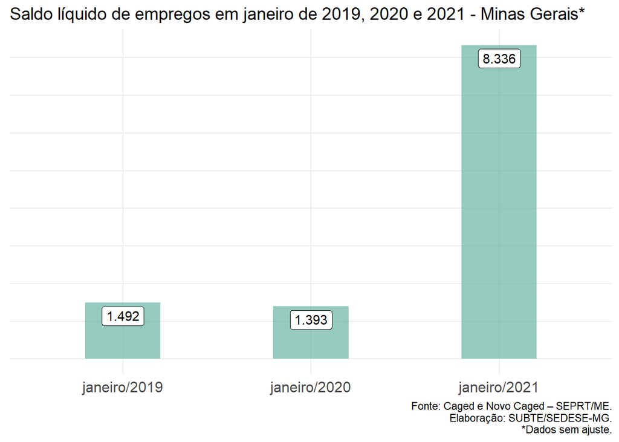

### **Resultado Estadual por região**

O resultado do emprego na Região Metropolitana de Belo Horizonte (RMBH) foi positivo em janeiro de 2021. Houve criação de 3.149 postos de trabalho formais, correspondendo à diferença entre admitidos (48.814) e desligados (45.665).

No interior do estado, foram criados 5.187 postos de trabalho, resultado da diferença entre a admissão de 90.917 empregados e o desligamento de 85.730 trabalhadores com carteira assinada.

**Saldo de Empregos Formais por região geográfica de Minas Gerais em 2021***

|  | Admissões | Desligamentos | Saldo |
| --- | --- | --- | --- |
| Interior | 90.917 | 85.730 | 5.187 |
| RMBH | 48.814 | 45.665 | 3.149 |
| Total | 139.731 | 131.395 | 8.336 |

Fonte: Novo CAGED (Sem ajuste). Elaboração: SUBTE/SEDESE-MG.

### **Resultado Estadual por município**

Entre os municípios mineiros, em janeiro de 2021, Belo Horizonte (2.095), Nova Serrana (1.009) e Vespasiano (459) lideraram o ranking dos maiores saldos. Os saldos mais baixos entre os municípios foram registrados em Ipatinga (-713), Varginha (-396) e Araxá (-341).

#### Mapa municípios

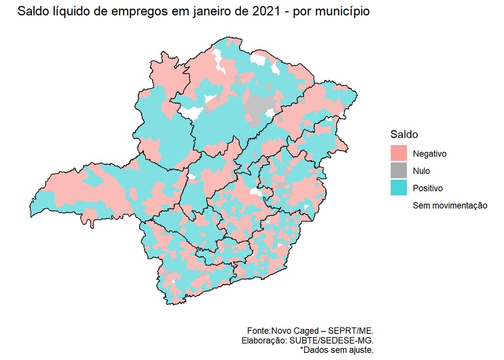

#### Tabela maiores e menores saldos

**Ranking dos municípios de Minas Gerais por saldo de empregos em janeiro de 2021**

| Maiores saldos Município | Maiores saldos Saldo | Menores saldos Município | Menores saldos Saldo |
| --- | --- | --- | --- |
| Belo Horizonte | 2.095 | Ipatinga | -713 |
| Nova Serrana | 1.009 | Varginha | -396 |
| Vespasiano | 459 | Araxá | -341 |
| Paracatu | 457 | Coronel Fabriciano | -179 |
| Patos de Minas | 423 | Tapira | -169 |
| Extrema | 352 | Ibiá | -157 |
| Betim | 349 | Contagem | -139 |
| Comendador Gomes | 336 | Congonhas | -134 |
| Pouso Alegre | 330 | Uberlândia | -130 |
| Ubá | 287 | Serra do Salitre | -122 |

Fonte: Novo CAGED (sem ajuste). Elaboração: SUBTE/SEDESE-MG.

### **Resultado Estadual por Setor de Atividade Econômica**

Em Minas Gerais, dentre os cinco setores de atividade econômica considerados no estudo, quatro apresentaram resultado positivo na criação de postos de trabalho e apenas um apresentou saldo negativo. Indústria, Construção, Serviços e Agropecuária criaram juntos 12.895 empregos, enquanto Comércio foi responsável pela eliminação de 4.559 postos de trabalho.

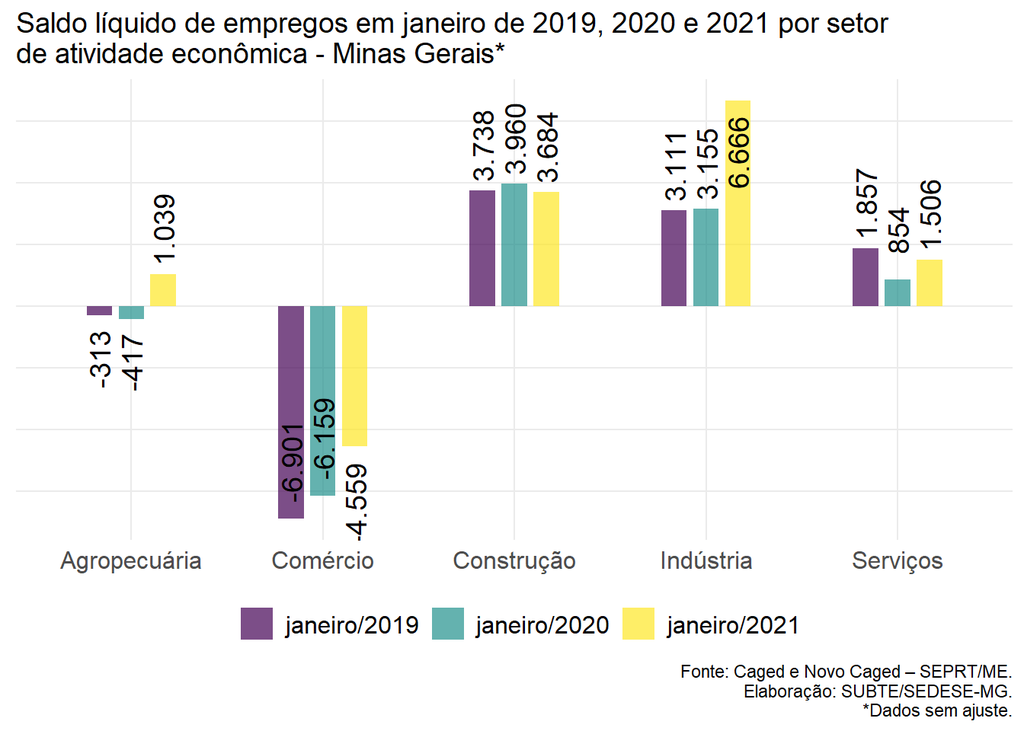